# Satellite tag derived movements of Aus SRW at Kerguelen

Virginia Andrews-Goff

15 March, 2024, 16:17

This RMarkdown file delves into the satellite tag derived SRW movements from Kate Sprogis’ deployments on Aus SRW. As it’s likely that the full tracks will be used in other projects, **I have restricted the detailed work to the area adjacent to Kerguelen.**

What data was collected for these three whales that use the Kerguelen region?  
Whale 235409 setup file indicates that all histograms were disabled.  
Whale 235410 setup file indicates that all histograms were disabled.  
Whale 235414 - there is min/max depth, histograms, dive shape.  
Min/max depth = min and max depths per 6 hour summary window.  
Behaviour - Each row of this spreadsheet represents one type of behavior reported by the instrument.  
Histograms - data including Time at Depth, Time at Temperature, Dive Durations, Dive Depths.  
Series - Subsampled archive data = less detailed dive profiles essentially.  
Proposed workflow: 1) Process all Argos locations within the ssm/move persistence framework; 2) Generate locations for the relevant dive data files; 3) Subset to Kerguelen region and 4) Charactertise horizontal and vertical behaviour in the area.  
Get ARGOS location data and dive data:

```r
raw_argos_df_WA <- ldply(WA_tags, function(x){read.csv(paste(path_tags_WA,"/", x, "/", x, "-Locations.csv", sep=""), stringsAsFactors = F, header = T)})

#dive associated files
fn <- '235414'
behav_WA <- read.csv(paste(path_tags_WA,"/", fn, "/", fn, "-Behavior.csv", sep=""), stringsAsFactors = F, header = T)
series_WA <- read.csv(paste(path_tags_WA,"/", fn, "/", fn, "-Series.csv", sep=""), stringsAsFactors = F, header = T)
minmax_WA <- read.csv(paste(path_tags_WA,"/", fn, "/", fn, "-MinMaxDepth.csv", sep=""), stringsAsFactors = F, header = T)
histos_WA <- read.csv(paste(path_tags_WA,"/", fn, "/", fn, "-Histos.csv", sep=""), stringsAsFactors = F, header = T)
```

Get deployment information:

```r
deploy_df_WA <- read.csv(paste(path_deploy_WA,"/", 'Tags deployed_Australia_2022.csv', sep=""))

#Filter by deployed
deploy_df_WA <- deploy_df_WA[!deploy_df_WA$Deployed=="Not deployed",]
```

**1- ARGOS TRACKS**

**1.1 - Cleaning raw tracks**

Just a few things to modify on the raw tracks. Argos Kalman Filter (or Kalman Smoother) data should have 8 columns in the following order: id, date, lc, lon, lat. Where date can be a POSIX object or text string in YYYY-MM-DD HH:MM:SS format. lc (location class) can include the following values: 3, 2, 1, 0, A, B, Z. Class Z values are assumed to have the same error variances as class B. Then smaj, smin, eor that contain Argos error ellipse variables (in m for smaj, smin and deg for eor).

```r
# remove useless columns and rename columns with shorter names
raw_argos_df_WA <- raw_argos_df_WA[c("Ptt", "Date", "Quality", "Longitude", "Latitude", "Error.Semi.major.axis", "Error.Semi.minor.axis", "Error.Ellipse.orientation")]
names(raw_argos_df_WA) <- c("id", "date", "lc", "lon", "lat", "smaj", "smin", "eor")

#Format the date - should be 'yyyy-mm-dd hh:mm:ss"
raw_argos_df_WA$date <- as.POSIXct(raw_argos_df_WA$date, format = "%H:%M:%S %d-%b-%Y", tz="GMT")

# Order the data by id and date
raw_argos_df_WA <- raw_argos_df_WA[order(raw_argos_df_WA$id, raw_argos_df_WA$date),]

# Remove data generated before tag deployment (testing for example)
deploy_df_WA$deploy_dte <- dmy(deploy_df_WA$Deployed, tz = "GMT")
deploy_df_WA<- deploy_df_WA[!is.na(deploy_df_WA$deploy_dte),] #get rid of those NAs
deploy_df_WA$id <- deploy_df_WA$PTT.ID
raw_argos_df_WA <- ddply(deploy_df_WA, ~ id, function(d){
  dates <- d[c("deploy_dte")]
  r <- raw_argos_df_WA[raw_argos_df_WA$date >= dates[1,1] &
                    raw_argos_df_WA$id == d$id[1],]
  return(r)
})
```

How many tags do we have?

```r
length(unique(raw_argos_df_WA$id)) #3
```

```
## [1] 3
```

How many raw positions per tag do we have?

```r
table(raw_argos_df_WA$id)
```

```
##
## 235409 235410 235414
##   1472   2595    968
```

Are some of these NAs?

```r
raw_argos_df_WA <- raw_argos_df_WA[!is.na(raw_argos_df_WA$lat),] # nope, all good
table(raw_argos_df_WA$id)
```

```
##
## 235409 235410 235414
##   1472   2595    968
```

```r
# Save to outputs folder
#save(raw_argos_df_WA, file = paste(file.path(here::here('Outputs')), "/raw_argos_df_WA.RData", sep=""))
```

**1.2 - Visualising raw tracks**

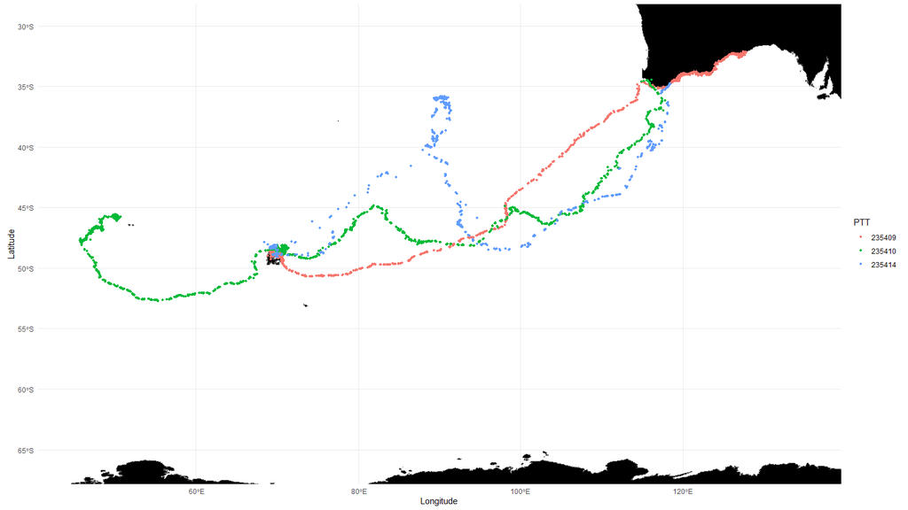

```r
## 1. run these commented lines just one time
#map_df <- st_as_sf(geodata::world(resolution = 3, path = tempdir()))
#saveRDS(map_df, "map_df.rds")

map_df <- readRDS("map_df.rds")
map_df <- filter(map_df, NAME_0 %in% c("Australia", "Antarctica", "South Africa", "Heard Island and McDonald Islands", "French Southern Territories"))

bb_WA <- st_bbox(c(xmin = 45, ymin = -66, xmax = 135, ymax = -30))

ggplot(map_df) +
  geom_sf(fill = "black", lwd = 0) +
  geom_point(data = raw_argos_df_WA, size=1.2, aes(lon, lat, colour = as.factor(id)))  +
  xlim(45,135) +
  ylim(-66, -30) +
  theme_minimal() +
  guides(color = guide_legend(title = "PTT")) +
  xlab("Longitude") +
  ylab("Latitude")
```

**2- CLEANING UP THE ARGOS TRACKS**

```r
pre_dup <- nrow(raw_argos_df_WA) # to get the current number of data points

# create dummy variable
raw_argos_df_WA$index <- c(1:nrow(raw_argos_df_WA))

# run each tag in a loop check to check for duplicates
# if there is a time duplicate, select the best quality position or simply the first position
raw_argos_df_WA <- ddply(raw_argos_df_WA, ~id, function(d){
  toremove <- c()
  for (i in c(2:nrow(d))) {
    if (d$date[i] == d$date[i-1]) {
      dd <- d[(i-1):i,]
      r <- dd[dd$lc == ave(dd$lc, FUN = min), "index"] # find the lowest quality
      toremove <- c(toremove, r[1]) #select first element of r in case both locations have the same lq
    }
  }
  if (length(toremove) > 0){d <- d[!(d$index %in% toremove), ]}
  return(d)
})
# remove dummy variable
raw_argos_df_WA$index <- NULL
```

How many duplicates?

```r
pre_dup - nrow(raw_argos_df_WA) # to get an understanding of how many duplicates were removed; n=131
```

```
## [1] 131
```

**3- PREPARING FOR THE STATE SPACE MODEL**  
Accounting for the natural time step in data set as well as any duty cycling. This is used to make decisions around modelling time steps and segmentation. Applying a time step probably won’t be necessary for these analyses but it’s here just in case.

```r
# Look at the time difference between locations

filtered_argos_df_WA <- raw_argos_df_WA #we haven't yet filtered it, assigning the name filtered_argos_df so I don't have to change a heap of code below
time_diff_hours_df_WA <- ddply(filtered_argos_df_WA, ~id, function(d){
  d$time_diff_hours <- NA
  for (i in 2:nrow(d)){
    d$time_diff_hours[i] = as.numeric(difftime(d$date[i], d$date[i-1], units = "hours"))}
  return(d)
})
```

Mean time difference between locations (in hours):

```r
mts <- aggregate(time_diff_hours~id, time_diff_hours_df_WA, mean)
mts #this is the mean time step
```

```
##       id time_diff_hours
## 1 235409        1.849449
## 2 235410        1.871440
## 3 235414        3.564068
```

Max time difference between locations (in hours):

```r
mxts <- aggregate(time_diff_hours~id, time_diff_hours_df_WA, max)
mxts# this is the max time step
```

```
##       id time_diff_hours
## 1 235409        13.84472
## 2 235410        31.35000
## 3 235414       142.24444
```

Min time difference between locations (in hours):

```r
mnts <- aggregate(time_diff_hours~id, time_diff_hours_df_WA, min)
mnts # this is the minimum time step
```

```
##       id time_diff_hours
## 1 235409    0.0013888889
## 2 235410    0.0002777778
## 3 235414    0.0011111111
```

Median time difference between locations (in hours):

```r
mets <- aggregate(time_diff_hours~id, time_diff_hours_df_WA, median)
mets # this is the median time step
```

```
##       id time_diff_hours
## 1 235409       0.9244444
## 2 235410       0.8277778
## 3 235414       0.5858333
```

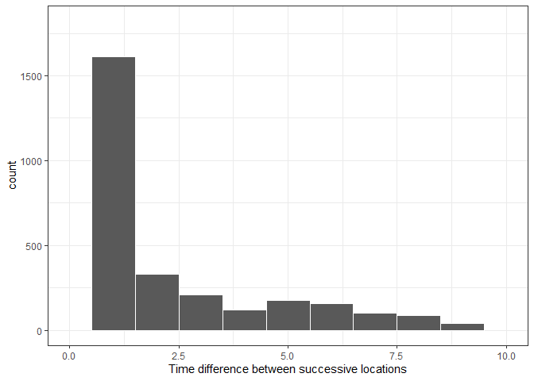

```r
# histogram of the time differences between locations
ggplot(time_diff_hours_df_WA, aes(time_diff_hours)) + geom_histogram(binwidth = 1, col ="white", na.rm = T) + theme_bw() + xlim(c(0,10)) + xlab("Time difference between successive locations")
```

I tend to split tracks with data gaps > 24h. This code is easily adapted to whatever split looks sensible. Below I have chosen 48 hours.

```r
trackseg_argos_df_WA <- ddply(time_diff_hours_df_WA, ~id, function(d){
ind <- which(d$time_diff_hours > 48) #48 = 48 hours
d$mark <- 0
d$mark[ind] <- 1
d$track_seg <- cumsum(d$mark)
  return(d)
})

# Now create a new id based on track segment
trackseg_argos_df_WA$track_id <- paste(trackseg_argos_df_WA$id, "_", trackseg_argos_df_WA$track_seg, sep="")
```

Does 48h segmentation look sensible? Looks pretty good:

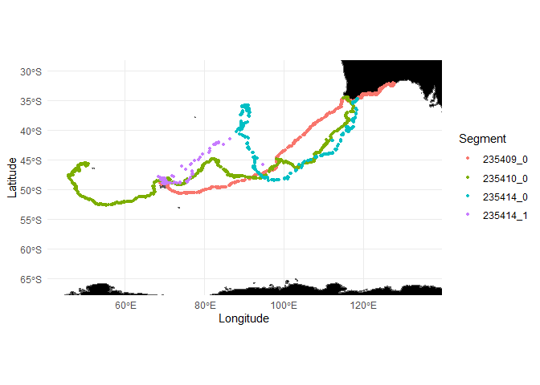

```r
ggplot(map_df) +
  geom_sf(fill = "black", lwd = 0) +
  geom_point(data = trackseg_argos_df_WA, size=1.2, aes(lon, lat, colour = as.factor(track_id)))  +
  xlim(45,135) +
  ylim(-66, -30) +
  theme_minimal() +
  guides(color = guide_legend(title = "Segment")) +
  xlab("Longitude") +
  ylab("Latitude")
```

```r
table(trackseg_argos_df_WA$track_id)  #looks good - especially for retaining Kerguelen info
```

```
##
## 235409_0 235410_0 235414_0 235414_1
##     1432     2514      785      173
```

```r
#save(trackseg_argos_df_WA, file = paste(file.path(here::here('Outputs')), "/trackseg_argos_df_WA.RData", sep=""))
#write.csv(trackseg_argos_df_WA, file = paste(file.path(here::here('Outputs')), "/trackseg_argos_df_WA.csv", sep=""), row.names = F)
```

Now that we’ve segmented the tracks, it would be a good idea to revisit the time differences to determine the time step for the ssm. We’ll look at the time differences within each track segment this time.

```r
# Clean up the file first

seg_diff_hours_df_WA <- ddply(trackseg_argos_df_WA, ~track_id, function(d){
  d$seg_diff_hours <- NA
  for (i in 2:nrow(d)){
    d$seg_diff_hours[i] = as.numeric(difftime(d$date[i], d$date[i-1], units = "hours"))}
  return(d)
})
```

Mean time difference between locations in track segments (in hours):

```r
mts <- aggregate(seg_diff_hours~track_id, seg_diff_hours_df_WA, mean)
mts #this is the mean time step
```

```
##   track_id seg_diff_hours
## 1 235409_0       1.849449
## 2 235410_0       1.871440
## 3 235414_0       3.187574
## 4 235414_1       4.473902
```

Max time difference between locations in track segments (in hours):

```r
mxts <- aggregate(seg_diff_hours~track_id, seg_diff_hours_df_WA, max)
mxts# this is the max time step
```

```
##   track_id seg_diff_hours
## 1 235409_0       13.84472
## 2 235410_0       31.35000
## 3 235414_0       23.21056
## 4 235414_1       34.76583
```

Min time difference between locations in track segments (in hours):

```r
mnts <- aggregate(seg_diff_hours~track_id, seg_diff_hours_df_WA, min)
mnts # this is the minimum time step
```

```
##   track_id seg_diff_hours
## 1 235409_0   0.0013888889
## 2 235410_0   0.0002777778
## 3 235414_0   0.0011111111
## 4 235414_1   0.0075000000
```

Median time difference between locations in track segments (in hours):

```r
mets <- aggregate(seg_diff_hours~track_id, seg_diff_hours_df_WA, median)
mets # this is the median time step
```

```
##   track_id seg_diff_hours
## 1 235409_0      0.9244444
## 2 235410_0      0.8277778
## 3 235414_0      0.5663889
## 4 235414_1      0.7438889
```

To choose a time step, for the time being I’ll be informed by the “text book approach.” First of all the mean time diff is:

```r
mean(mts$seg_diff_hours) #2.85
```

```
## [1] 2.845591
```

This indicates 1 Argos location every ~3 hours. As a general rule of thumb, generating one ssm location for 3 Argos locations is a good approach, though often somewhat conservative. It’s a start. So, if I need to time step later, I’ll run with a 6h, 9h and 12h model to compare. Best to start with no time step unless future analyses require it.

**4- THE STATE SPACE MODEL AND MOVE PERSISTENCE MODEL**  
aniMotum provides a move persistence model in state-space form to allow simultaneous estimation of move persistence and location states, and this is invoked via fit_ssm() by specifying model = “mp”. Apparently, this model can only be fit to individuals separately but when your run the code on tracks together, it appears to work.

We will generate a SSM location estimate at each oberved location estimate time. The SSM location estimate accounts for Argos location error and has an associated value of move persistence (continuous-valued behavioural index). Move persistence estimates the time-varying autocorrelation in speed and directionality along an animal’s track. The resulting move persistence (γ) value at each location provides an index of behaviour (between 0-1). Move persistence values approaching 1 indicate faster, straighter movements associated with transit behaviour, while move persistence values approaching 0 indicate slower, more tortuous movements termed ‘area restricted search’ (assumed to be foraging/resting/breeding behaviour).

```r
to_model_WA <- trackseg_argos_df_WA[,c("track_id", "date", "lc", "lon", "lat", "smaj", "smin", "eor")]
colnames(to_model_WA)[1] <- "id"

#SSM locations at observed Argos location times
fit_ksrw <- fit_ssm(to_model_WA, vmax=10, model = "mp", time.step=NA, control = ssm_control(verbose = 0)) #worked
```

```r
#SSM locations at 6h time step
fit_ksrw_6h <- fit_ssm(to_model_WA, vmax=10, model = "mp", time.step=6, control = ssm_control(verbose = 0), map = list(psi = factor(NA)))
```

These plots demonstrate the uncertainty associated with the move persistence parameter and look pretty standard for this kind of data.

```
## $`235409_0`
```

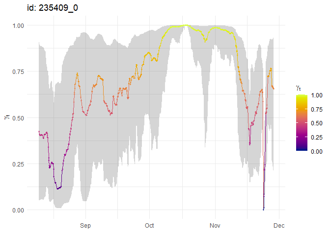

```
##
## $`235410_0`
```

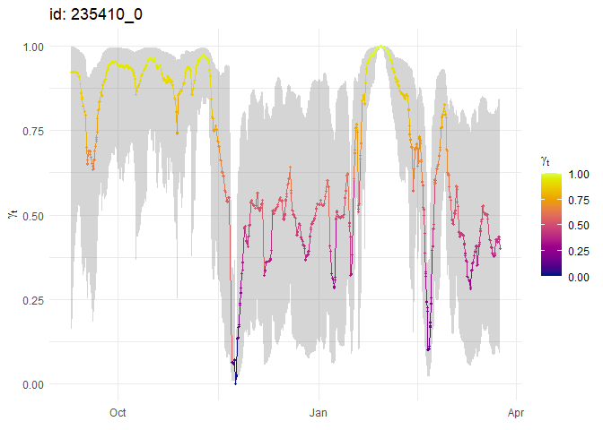

```
##
## $`235414_0`
```

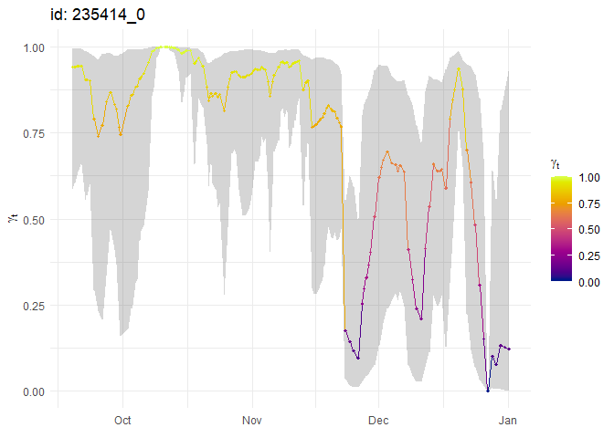

```
##
## $`235414_1`
```

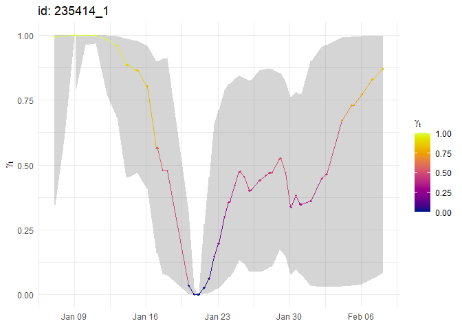

```r
plot(fit_ksrw, what = "predicted", type = 3, normalise = TRUE) #large uncertainties associated with gamma
```

This is the full map of state space modelled locations colour coded by move persistence:

```r
srw_mp <- map(fit_ksrw, what="fitted") ##model appears to have worked beautifully
```

```
## using map scale: 10
```

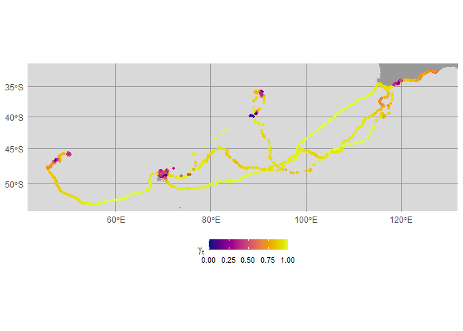

```r
#ggsave(srw_mp, file = paste(file.path(here::here('Outputs')), "/srw_move_persistence.jpeg"))
srw_mp
```

Now to zoom into the area of interest around Kergeulen. This is all three individuals mapped together then separately.

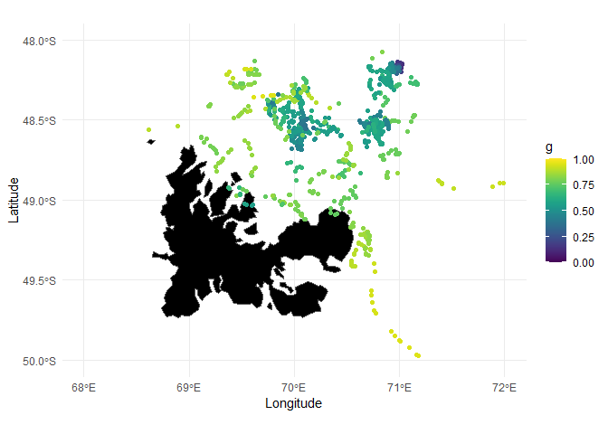

```r
mpm_KI_srw <- grab(fit_ksrw, what="fitted", as_sf=FALSE, normalise = TRUE, group=TRUE)
mpm_KI_srw_6h <- grab(fit_ksrw_6h, what="predicted", as_sf=FALSE, normalise = TRUE, group=TRUE)


p_kerg <- ggplot(map_df) +
  geom_sf(fill = "black", lwd = 0) +
  geom_point(data = mpm_KI_srw, size=1.5, aes(lon, lat, colour = g))  +
 xlim(68,72) +
  ylim(-50, -48) +
  theme_minimal()  +
  sc +
  xlab("Longitude") +
  ylab("Latitude")

p_kerg
```

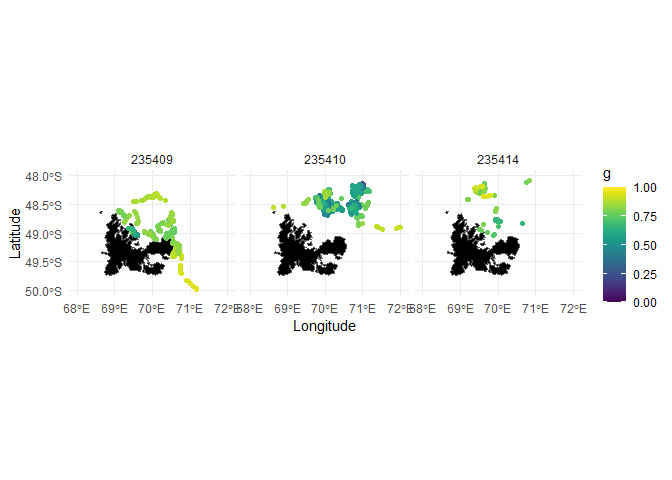

```r
p_kerg + facet_wrap(~substr(id, 1,6))
```

```r
#ggsave(p_kerg, file = paste(file.path(here::here('Outputs')), "/Kerguelen_SRW.jpeg", sep=""), dpi = 300, width = 14, height = 8, bg="white")
```

Might be worthwhile pulling in the bathymetry however, there is not a huge amount of depth variability in the area around Kerguelen (though clearly there is a very decent drop off to the east).

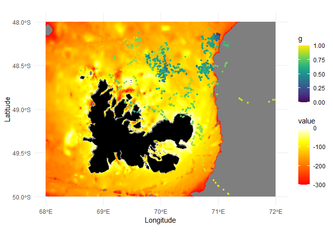

```r
bathy_geb <- raster(paste(file.path(here::here('Data', 'Enviro')),"/gebco_2023_n-48.0_s-50.0_w68.0_e72.0.tif", sep=""))
bathy_geb_spdf <- as(bathy_geb, "SpatialPixelsDataFrame")
bathy_geb_df <- as.data.frame(bathy_geb_spdf)
colnames(bathy_geb_df) <- c("value", "x", "y")

mpm_bathy <- ggplot(map_df) +
  geom_sf(fill = "black", lwd = 0) +
   geom_tile(mapping = aes(x, y, fill = value), data=bathy_geb_df) +
     scale_fill_gradientn(limits=c(-300, 0), colours = heat.colors(225)) +
  geom_sf(fill = "black", lwd = 0) +
  geom_point(data = mpm_KI_srw, size=1.2, aes(lon, lat, colour = g))  +
xlim(68,72) +
  ylim(-50, -48) +
  theme_minimal()  +
  sc +
  xlab("Longitude") +
  ylab("Latitude")

mpm_bathy #I restricted the plotting to the top 300m to help see depth variation
```

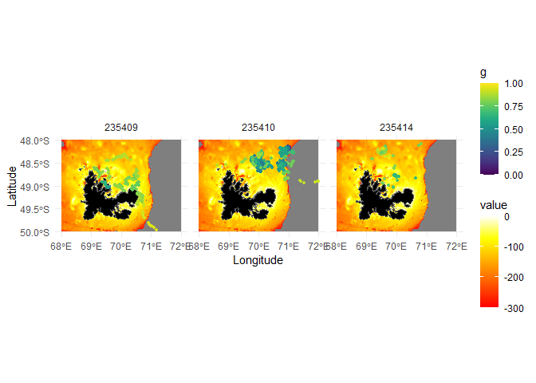

```r
mpm_bathy + facet_wrap(~substr(id, 1,6))
```

Also had a play with the bathymetric gradient - doesn’t really help with the visualisation at all.

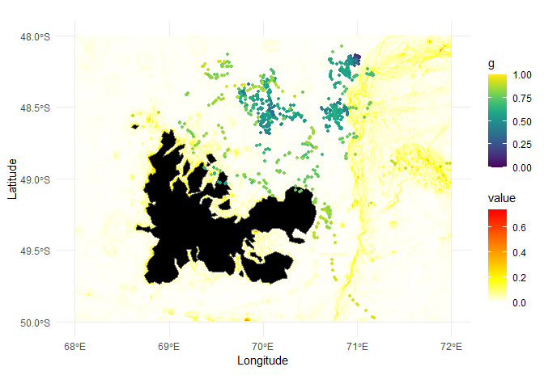

```r
bathy_grad <- terrain(bathy_geb, opt = "slope")
#writeRaster(bathy_grad, paste(file.path(here::here('Data', 'Enviro')),"/bathy_grad.tif", sep=""), format = "GTiff")
bathy_grad_spdf <- as(bathy_grad, "SpatialPixelsDataFrame")
bathy_grad_df <- as.data.frame(bathy_grad_spdf)
colnames(bathy_grad_df) <- c("value", "x", "y")

ggplot(map_df) +
  geom_sf(fill = "black", lwd = 0) +
   geom_tile(mapping = aes(x, y, fill = value), data=bathy_grad_df) +
     scale_fill_gradientn(colours = rev(heat.colors(225))) +
  geom_sf(fill = "black", lwd = 0) +
  geom_point(data = mpm_KI_srw, size=1.2, aes(lon, lat, colour = g))  +
xlim(68,72) +
  ylim(-50, -48) +
  theme_minimal()  +
  sc +
  xlab("Longitude") +
  ylab("Latitude")
```

Take a look at the move persistence across the time period that captures the time located by Kerguelen - defined by locations that are <= 72 longitude but >= 68 longitude . Grab the relevant date range first and go from there.

Crop the dataset to just the portion of track in the map:

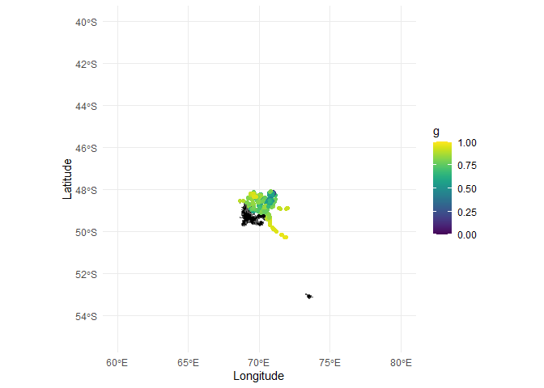

```r
mpm_KI_srw$in_area <- "no"
mpm_KI_srw$in_area[mpm_KI_srw$lon <= 72 & mpm_KI_srw$lon >=68] <- "yes"

mpm_KI_srw_6h$in_area <- "no"
mpm_KI_srw_6h$in_area[mpm_KI_srw_6h$lon <= 72 & mpm_KI_srw_6h$lon >=68] <- "yes"

#check the data limits
ggplot(map_df) +
  geom_sf(fill = "black", lwd = 0) +
  geom_point(data = mpm_KI_srw[mpm_KI_srw$in_area=="yes",], size=1.5, aes(lon, lat, colour = g))  +
 xlim(60,80) +
ylim(-55, -40) +
  theme_minimal()  +
  sc +
  xlab("Longitude") +
  ylab("Latitude")
```

Summary of each individual’s Argos locations while “in area”:

```r
in_area_summ <- ddply(mpm_KI_srw[mpm_KI_srw$in_area=="yes",], "id", summarise,
 duration = max(date) - min(date),
 nlocs = length(id),
 start= min(date),
 end= max(date),
 lat1 = min(lat),
 lat2 = max(lat),
 lon1 = min(lon),
 lon2 = max(lon),
 mean.g = mean(g))

in_area_summ
```

```
##         id      duration nlocs               start                 end
## 1 235409_0 18.26874 days   263 2023-11-10 01:58:40 2023-11-28 08:25:39
## 2 235410_0 71.53336 days   670 2022-11-11 17:18:26 2023-01-22 06:06:28
## 3 235414_1 19.00662 days    74 2023-01-20 02:47:39 2023-02-08 02:57:11
##        lat1      lat2     lon1     lon2    mean.g
## 1 -50.29273 -48.31205 69.11136 71.88621 0.8282229
## 2 -48.92955 -48.13642 68.61253 71.98559 0.5681983
## 3 -49.03144 -48.07504 69.18280 70.83655 0.8041506
```

Take a look at each individuals move persistence across the time period that they are “in area.”

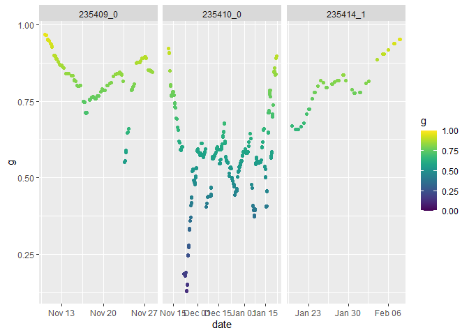

```r
g_plot <- ggplot(mpm_KI_srw[mpm_KI_srw$in_area=="yes",], aes(x=date, y=g, color=g)) +
  geom_point() +
  sc
facet(g_plot, facet.by = "id", scales = "free_x")
```

```r
#ggsave(facet(g_plot, facet.by = "id", scales = "free_x"), file = paste(file.path(here::here('Outputs')), "/g_in_area.jpeg", sep=""), dpi = 300, width = 14, height = 8, bg="white")
```

Individual 235410 is clearly engaged in area restricted search around Kerguelen. The other two whales, 235409 and 235414 (who has the associated dive data) aren’t as convincing - however, common sense tells us that they are resident and resident whales are probably foraging.  
**TIME SPENT GRID**  
A time spent grid might be a useful representation of how the whales use the region.

Start by applying the trip function:

```r
mpm_KI_srw_tsp <- mpm_KI_srw[,c(3,4,2,1)]
sp::coordinates(mpm_KI_srw_tsp)<- c("lon","lat")

#make trip
tr_df_all <- trip(mpm_KI_srw_tsp,c("date","id"))

tr_df_all
```

```
##
## Object of class trip
##   tripID ("id") No.Records  startTime ("date")    endTime ("date")
## 1      235409_0       1150 2023-08-10 01:51:58 2023-11-28 08:25:39
## 2      235410_0       1896 2022-09-09 14:58:55 2023-03-24 13:54:39
## 3      235414_0        614 2022-09-19 00:08:23 2023-01-01 03:11:51
## 4      235414_1        123 2023-01-07 01:26:31 2023-02-08 02:57:11
##    tripDuration
## 1 110.2734 days
## 2 195.9554 days
## 3 104.1274 days
## 4 32.06296 days
##
##   data.columns data.class
## 1         date    POSIXct **trip DateTime**
## 2           id  character **trip ID**
```

Create an appropriate grid - I’ve gone with 0.25 degrees by 0.25 degrees here:

```r
# ser the grid at 0.25 degrees by 0.25 degrees
r_g_all <- GridTopology(c(45,-53), c(0.25,0.25), c(336,88))

r_g_all
```

```
##                       X1     X2
## cellcentre.offset  45.00 -53.00
## cellsize            0.25   0.25
## cells.dim         336.00  88.00
```

```r
#trip grid
tg_all_1 <- tripGrid(x=tr_df_all,grid = r_g_all, method="pixellate")

tg_all_1$z <- tg_all_1$z/86400

tg_all_1$ind <- 1:nrow(tg_all_1)

#spplot(tg_all_1, sp.layout=list("sp.points",tr_df_all, #col=as.factor(tr_df_all$id), pch=15, cex=0.8))

# convert to spatialgriddataframe to spatialpixelsdataframe then to df
tg_all_1_spdf <- as(tg_all_1, "SpatialPixelsDataFrame")
tg_all_1_df <- as.data.frame(tg_all_1_spdf )
head(tg_all_1_df)
```

```
##   z ind    s1     s2
## 1 0   1 45.00 -31.25
## 2 0   2 45.25 -31.25
## 3 0   3 45.50 -31.25
## 4 0   4 45.75 -31.25
## 5 0   5 46.00 -31.25
## 6 0   6 46.25 -31.25
```

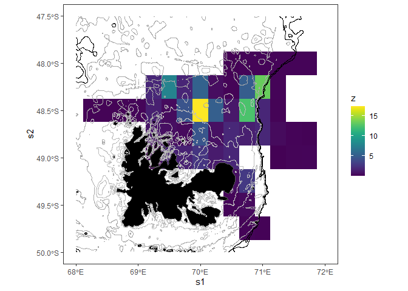

```r
tg_all_1_df$z[tg_all_1_df$z==0] <- NA

# zoom in to Kerguelen - add bathymetry
bathy_geb_wide <- raster(paste(file.path(here::here('Data', 'Enviro')),"/gebco_2023_n-43.0_s-53.0_w60.0_e80.0.tif", sep=""))
bathy_geb_spdf_wide <- as(bathy_geb_wide, "SpatialPixelsDataFrame")
bathy_geb_df_wide <- as.data.frame(bathy_geb_spdf_wide)
colnames(bathy_geb_df_wide) <- c("value", "x", "y")



  ggplot(map_df)+
    geom_sf(fill = "black", lwd = 0) +
  geom_tile(data=tg_all_1_df,aes(x=s1,y=s2,fill = z,width=0.25,height=0.25),lwd=0.5)+
  scale_fill_viridis(option = "D", na.value="white")+
  theme_bw()+ theme(panel.grid=element_blank()) +
    geom_sf(fill = "black", lwd = 0) +
  geom_contour(data = bathy_geb_df_wide,
               aes(x=x, y=y, z=value),
               breaks=c(-50, -100),
               size=c(0.3),
               colour="grey") +
      geom_contour(data = bathy_geb_df_wide,
               aes(x=x, y=y, z=value),
               breaks=c(-150, -200),
               size=c(0.3),
               colour="darkgrey") +
         geom_contour(data = bathy_geb_df_wide,
               aes(x=x, y=y, z=value),
               breaks=c(-250, -300),
               size=c(0.3),
               colour="black") +
    xlim(68,72) +
ylim(-50, -47.5)
```

This time spent grid is for all three whales. The z (time spent) scale is in days, therefore, those areas that are green and yellow in colour are areas where the whales (together) have spent upwards of 10 days.

Take a look at the time spent grid per whale to determine whether there is similar horizontal habitat use in the area even with different occupancy lengths.  
**TIME SPENT - PTT 235409**

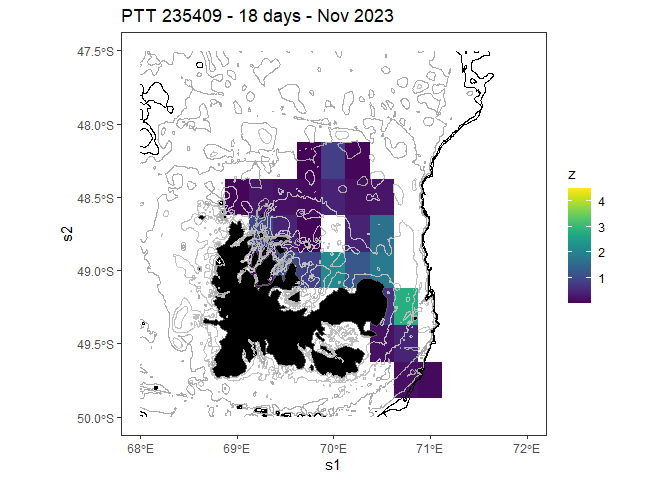

```r
mpm_KI_srw_tsp_235409 <- mpm_KI_srw[,c(3,4,2,1)]
mpm_KI_srw_tsp_235409 <- mpm_KI_srw_tsp_235409[substr(mpm_KI_srw_tsp_235409$id, 1, 6) == 235409,]
sp::coordinates(mpm_KI_srw_tsp_235409)<- c("lon","lat")

#make trip
tr_df_235409 <- trip(mpm_KI_srw_tsp_235409,c("date","id"))
#tr_df_235409

# ser the grid at 0.25 degrees by 0.25 degrees
r_g_235409 <- GridTopology(c(45,-53), c(0.25,0.25), c(336,88))

#r_g_235409

#plot(as.SpatialPolygons.GridTopology(r_g_235409))
#points(tr_df_235409)

#trip grid
tg_235409_0.25 <- tripGrid(x=tr_df_235409,grid = r_g_235409, method="pixellate")

tg_235409_0.25$z <- tg_235409_0.25$z/86400

tg_235409_0.25$ind <- 1:nrow(tg_235409_0.25)

#spplot(tg_235409_0.25, sp.layout=list("sp.points",tr_df_235409, #col=as.factor(tr_df_235409$id), pch=15, cex=0.8))

# convert to spatialgriddataframe to spatialpixelsdataframe then to df
tg_235409_0.25_spdf <- as(tg_235409_0.25, "SpatialPixelsDataFrame")
tg_235409_0.25_df <- as.data.frame(tg_235409_0.25_spdf )
#head(tg_235409_0.25_df)
tg_235409_0.25_df$z[tg_235409_0.25_df$z==0] <- NA

# zoom in to Kerguelen - add bathymetry
bathy_geb_wide <- raster(paste(file.path(here::here('Data', 'Enviro')),"/gebco_2023_n-43.0_s-53.0_w60.0_e80.0.tif", sep=""))
bathy_geb_spdf_wide <- as(bathy_geb_wide, "SpatialPixelsDataFrame")
bathy_geb_df_wide <- as.data.frame(bathy_geb_spdf_wide)
colnames(bathy_geb_df_wide) <- c("value", "x", "y")



  ggplot(map_df)+
    geom_sf(fill = "black", lwd = 0) +
  geom_tile(data=tg_235409_0.25_df,aes(x=s1,y=s2,fill = z,width=0.25,height=0.25),lwd=0.5)+
  scale_fill_viridis(option = "D", na.value="white")+
  theme_bw()+ theme(panel.grid=element_blank()) +
    geom_sf(fill = "black", lwd = 0) +
  geom_contour(data = bathy_geb_df_wide,
               aes(x=x, y=y, z=value),
               breaks=c(-50, -100),
               size=c(0.3),
               colour="grey") +
      geom_contour(data = bathy_geb_df_wide,
               aes(x=x, y=y, z=value),
               breaks=c(-150, -200),
               size=c(0.3),
               colour="darkgrey") +
         geom_contour(data = bathy_geb_df_wide,
               aes(x=x, y=y, z=value),
               breaks=c(-250, -300),
               size=c(0.3),
               colour="black") +
    xlim(68,72) +
ylim(-50, -47.5) +
    ggtitle("PTT 235409 - 18 days - Nov 2023")
```

**TIME SPENT - PTT 235410**

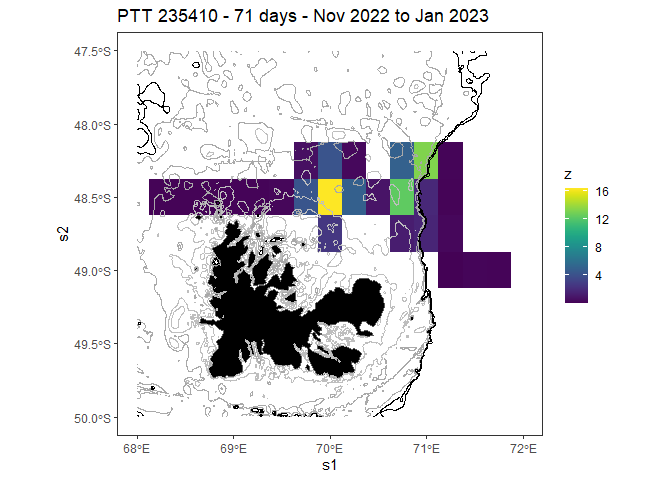

```r
mpm_KI_srw_tsp_235410 <- mpm_KI_srw[,c(3,4,2,1)]
mpm_KI_srw_tsp_235410 <- mpm_KI_srw_tsp_235410[substr(mpm_KI_srw_tsp_235410$id, 1, 6) == 235410,]
sp::coordinates(mpm_KI_srw_tsp_235410)<- c("lon","lat")

#make trip
tr_df_235410 <- trip(mpm_KI_srw_tsp_235410,c("date","id"))
#tr_df_235410

# ser the grid at 0.25 degrees by 0.25 degrees
r_g_235410 <- GridTopology(c(45,-53), c(0.25,0.25), c(336,88))

#r_g_235410

#plot(as.SpatialPolygons.GridTopology(r_g_235410))
#points(tr_df_235410)

#trip grid
tg_235410_0.25 <- tripGrid(x=tr_df_235410,grid = r_g_235410, method="pixellate")

tg_235410_0.25$z <- tg_235410_0.25$z/86400

tg_235410_0.25$ind <- 1:nrow(tg_235410_0.25)

#spplot(tg_235410_0.25, sp.layout=list("sp.points",tr_df_235410, #col=as.factor(tr_df_235410$id), pch=15, cex=0.8))

# convert to spatialgriddataframe to spatialpixelsdataframe then to df
tg_235410_0.25_spdf <- as(tg_235410_0.25, "SpatialPixelsDataFrame")
tg_235410_0.25_df <- as.data.frame(tg_235410_0.25_spdf )
#head(tg_235410_0.25_df)
tg_235410_0.25_df$z[tg_235410_0.25_df$z==0] <- NA

# zoom in to Kerguelen - add bathymetry
bathy_geb_wide <- raster(paste(file.path(here::here('Data', 'Enviro')),"/gebco_2023_n-43.0_s-53.0_w60.0_e80.0.tif", sep=""))
bathy_geb_spdf_wide <- as(bathy_geb_wide, "SpatialPixelsDataFrame")
bathy_geb_df_wide <- as.data.frame(bathy_geb_spdf_wide)
colnames(bathy_geb_df_wide) <- c("value", "x", "y")



  ggplot(map_df)+
    geom_sf(fill = "black", lwd = 0) +
  geom_tile(data=tg_235410_0.25_df,aes(x=s1,y=s2,fill = z,width=0.25,height=0.25),lwd=0.5)+
  scale_fill_viridis(option = "D", na.value="white")+
  theme_bw()+ theme(panel.grid=element_blank()) +
    geom_sf(fill = "black", lwd = 0) +
  geom_contour(data = bathy_geb_df_wide,
               aes(x=x, y=y, z=value),
               breaks=c(-50, -100),
               size=c(0.3),
               colour="grey") +
      geom_contour(data = bathy_geb_df_wide,
               aes(x=x, y=y, z=value),
               breaks=c(-150, -200),
               size=c(0.3),
               colour="darkgrey") +
         geom_contour(data = bathy_geb_df_wide,
               aes(x=x, y=y, z=value),
               breaks=c(-250, -300),
               size=c(0.3),
               colour="black") +
    xlim(68,72) +
ylim(-50, -47.5) +
    ggtitle("PTT 235410 - 71 days - Nov 2022 to Jan 2023")
```

**TIME SPENT - PTT 235414**

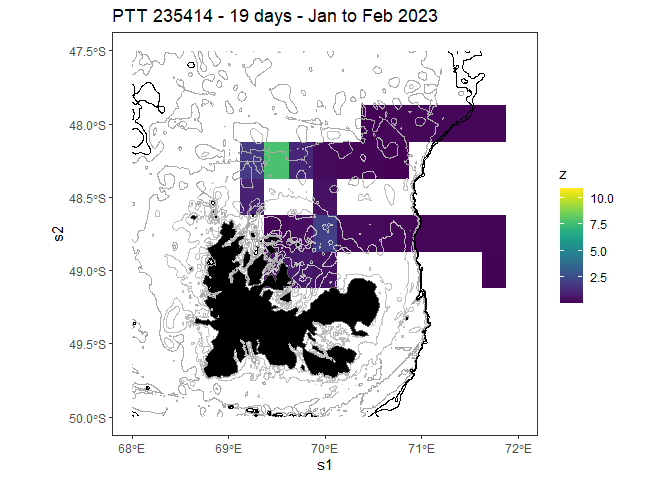

```r
mpm_KI_srw_tsp_235414 <- mpm_KI_srw[,c(3,4,2,1)]
mpm_KI_srw_tsp_235414 <- mpm_KI_srw_tsp_235414[substr(mpm_KI_srw_tsp_235414$id, 1, 6) == 235414,]
sp::coordinates(mpm_KI_srw_tsp_235414)<- c("lon","lat")

#make trip
tr_df_235414 <- trip(mpm_KI_srw_tsp_235414,c("date","id"))
#tr_df_235414

# ser the grid at 0.25 degrees by 0.25 degrees
r_g_235414 <- GridTopology(c(45,-53), c(0.25,0.25), c(336,88))

#r_g_235414

#plot(as.SpatialPolygons.GridTopology(r_g_235414))
#points(tr_df_235414)

#trip grid
tg_235414_0.25 <- tripGrid(x=tr_df_235414,grid = r_g_235414, method="pixellate")

tg_235414_0.25$z <- tg_235414_0.25$z/86400

tg_235414_0.25$ind <- 1:nrow(tg_235414_0.25)

#spplot(tg_235414_0.25, sp.layout=list("sp.points",tr_df_235414, col=as.factor(tr_df_235414$id), pch=15, cex=0.8))

# convert to spatialgriddataframe to spatialpixelsdataframe then to df
tg_235414_0.25_spdf <- as(tg_235414_0.25, "SpatialPixelsDataFrame")
tg_235414_0.25_df <- as.data.frame(tg_235414_0.25_spdf )
#head(tg_235414_0.25_df)
tg_235414_0.25_df$z[tg_235414_0.25_df$z==0] <- NA

# zoom in to Kerguelen - add bathymetry
bathy_geb_wide <- raster(paste(file.path(here::here('Data', 'Enviro')),"/gebco_2023_n-43.0_s-53.0_w60.0_e80.0.tif", sep=""))
bathy_geb_spdf_wide <- as(bathy_geb_wide, "SpatialPixelsDataFrame")
bathy_geb_df_wide <- as.data.frame(bathy_geb_spdf_wide)
colnames(bathy_geb_df_wide) <- c("value", "x", "y")



p_tsp_235414 <-   ggplot(map_df)+
    geom_sf(fill = "black", lwd = 0) +
  geom_tile(data=tg_235414_0.25_df,aes(x=s1,y=s2,fill = z,width=0.25,height=0.25),lwd=0.5)+
  scale_fill_viridis(option = "D", na.value="white")+
  theme_bw()+ theme(panel.grid=element_blank()) +
    geom_sf(fill = "black", lwd = 0) +
  geom_contour(data = bathy_geb_df_wide,
               aes(x=x, y=y, z=value),
               breaks=c(-50, -100),
               size=c(0.3),
               colour="grey") +
      geom_contour(data = bathy_geb_df_wide,
               aes(x=x, y=y, z=value),
               breaks=c(-150, -200),
               size=c(0.3),
               colour="darkgrey") +
         geom_contour(data = bathy_geb_df_wide,
               aes(x=x, y=y, z=value),
               breaks=c(-250, -300),
               size=c(0.3),
               colour="black") +
    xlim(68,72) +
ylim(-50, -47.5) +
    ggtitle("PTT 235414 - 19 days - Jan to Feb 2023")

p_tsp_235414
```

Given the issues associated with interpolating dive locations (see below), a better approach may be to extract dive info for those higher use grid cells.

```r
proj4string(mpm_KI_srw_tsp_235414) <- CRS("+proj=longlat +datum=WGS84")
proj4string(tg_235414_0.25) <- CRS("+proj=longlat +datum=WGS84")

grid_cell <- sp::over(mpm_KI_srw_tsp_235414,tg_235414_0.25) #use over to extract the grid cell for each location
mpm_KI_srw_tsp_235414$grid_cell <- grid_cell$ind
mpm_KI_srw_tsp_235414$tsp <- grid_cell$z
```

Which grid cells are we interested in?

```r
subset(tg_235414_0.25_df, z > 2)
```

```
##               z   ind    s1     s2
## 6563   3.724082  6563 89.50 -36.00
## 6568   4.258751  6568 90.75 -36.00
## 7240  10.923568  7240 90.75 -36.50
## 7241   2.896869  7241 91.00 -36.50
## 10930  2.122227 10930 89.25 -39.25
## 10932  2.235885 10932 89.75 -39.25
## 22947  7.767536 22947 69.50 -48.25
## 23621  2.045131 23621 70.00 -48.75
```

The top two grid cells in the Kerguelen region are 22947 @ 7.8 days and 23621 @ 2 days. We can check these by adding locations to the map:

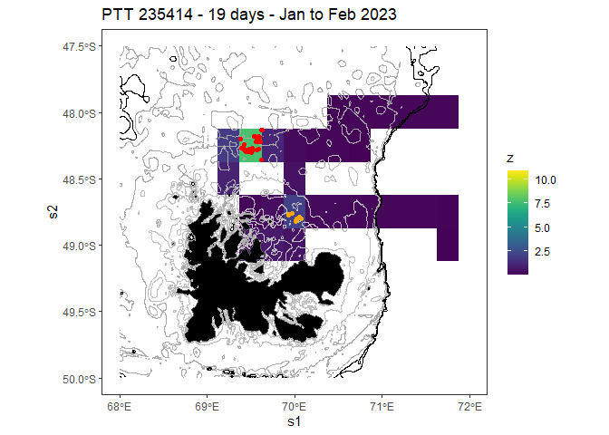

```r
mpm_KI_srw_tsp_235414 <- data.frame(mpm_KI_srw_tsp_235414)

p_tsp_235414 +
  geom_point(data = mpm_KI_srw_tsp_235414[mpm_KI_srw_tsp_235414$grid_cell==22947,], aes(lon, lat), colour="red")+
  geom_point(data = mpm_KI_srw_tsp_235414[mpm_KI_srw_tsp_235414$grid_cell==23621,], aes(lon, lat), colour="orange")
```

Time periods to check for dive data:  
Grid cell 22947:  
2023-01-26 02:55:07 - 2023-01-27 03:31:38  
2023-01-28 02:09:07 - 2023-01-29 03:47:03  
2023-01-31 00:58:51 - 2023-02-01 02:36:54  
2023-02-04 03:13:25 - 2023-02-05 01:43:19  
2023-02-06 01:11:16 - 2023-02-08 01:07:07  
Grid cell 23621  
2023-01-20 16:28:47 - 2023-01-22 03:28:20  
It would be interesting to know what depths these locations within high time spent grid cells are occurring over.

```r
coordinates(mpm_KI_srw_tsp_235414) <- c("lon", "lat")
bathy_extract_tsp_235414 <- raster::extract(bathy_geb, mpm_KI_srw_tsp_235414)
mpm_KI_srw_tsp_235414 <- data.frame(mpm_KI_srw_tsp_235414)
mpm_KI_srw_tsp_235414$bathy <- bathy_extract_tsp_235414

#range(mpm_KI_srw_tsp_235414$bathy[mpm_KI_srw_tsp_235414$grid_cell==22947])
#mean(mpm_KI_srw_tsp_235414$bathy[mpm_KI_srw_tsp_235414$grid_cell==22947])
#median(mpm_KI_srw_tsp_235414$bathy[mpm_KI_srw_tsp_235414$grid_cell==22947])

#range(mpm_KI_srw_tsp_235414$bathy[mpm_KI_srw_tsp_235414$grid_cell==23621])
#mean(mpm_KI_srw_tsp_235414$bathy[mpm_KI_srw_tsp_235414$grid_cell==23621])
#median(mpm_KI_srw_tsp_235414$bathy[mpm_KI_srw_tsp_235414$grid_cell==23621])
```

In the grid cell of highest time spent (22947 = 7.8 days), the associated locations are occurring over a mean depth of 143.5 m (range: 119 to 163m; median: 144m). In the grid cell of second highest time spent (23621 = 2 days), locations occur over 92.7m (range: 85 to 101m; median: 93m). I focus on these two grid cells here as hopefully later on, I can take a look at the dive behavior occuring within the time windows that these grid cells are occupied.

**5- DIVING BEHAVIOUR - TIME SERIES**  
For the dive associated data sets - the tag was programmed so that the transmission of behavior (dive shapes) and time series data was prioritised as high. The transmission of histograms was low. However, we can probably be confident that we’re missing information from all data sets.  
Dive data is pretty sparse as compared to the Argos location data that we were working with above. On top of that, we are also just looking at the one individual - 235414.  
According to our summary, whale 235414, was in area for 19 days from 2023-01-20 02:47:39 to 2023-02-08 02:57:11. I’ll attempt to summarise what the dive activity looked like across that period.  
Note: the tag was programmed so that the depth reading to determine the start and end of the dive was 0.5m. Dives less than 10 m and shorter than 10 s were ignored.

```r
locs_235414 <- to_model_WA[substr(to_model_WA$id, 1, 6) == 235414,]

series_WA$Day <- as.POSIXct(series_WA$Day, format="%d-%b-%Y", tz="GMT")
series_WA$gmt <- ymd_hms(paste(series_WA$Day, series_WA$Time), tz="GMT")

series_WA$seg_id <- "235414_0"
series_WA$seg_id[as.Date(series_WA$gmt) >= locs_235414$date[locs_235414$id=="235414_1"][1]] <- "235414_1"

#prediction times must be specified as a data.frame with id and POSIXt dates
pred_gmt_series <- series_WA[,c("gmt", "seg_id")]
colnames(pred_gmt_series) <- c("date", "id")

mp_series <- fit_ssm(locs_235414, vmax=10, model='crw', time.step=pred_gmt_series, map = list(psi = factor(NA)), control = ssm_control(verbose = 0))
```

```r
#ggsave(map(mp_series, what="predicted"), file = paste(file.path(here::here('Outputs')), "/dive_locations_235414.jpeg", sep=""), dpi = 300, width = 14, height = 8, bg="white")

dive_locs <- grab(mp_series, what = "predicted")
series_WA$dive_lon <- dive_locs$lon
series_WA$dive_lat <- dive_locs$lat

series_WA$in_area <- "no"
series_WA$in_area[series_WA$dive_lon <= 72 & series_WA$dive_lon >=68] <- "yes"

p_depth_series <- ggplot(series_WA[series_WA$in_area=="yes",], aes(gmt, Depth)) +
  geom_segment(aes(x=gmt, xend=gmt, y=0, yend=Depth)) +
  scale_y_reverse()

num_series_dives <- nrow(series_WA[series_WA$in_area=="yes",])
```

Here we have the dive profiles constructed around maximum dive depth against date. In this plot, that details the dive series around the Kerguelen region, we have 384 dives. It is likely that represents the minimum number of dives undertaken in the Kerguelen region. The other dive data sets will need to be used to supplement the dive story.

I’ve pulled in the move persistence time series data derived from the Argos movement data that we first worked with also.

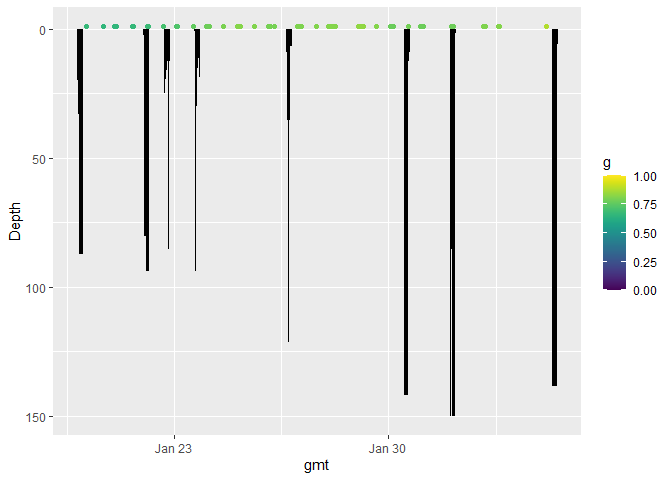

```r
p_depth_series +
  geom_point(data=mpm_KI_srw[mpm_KI_srw$id=="235414_1",], aes(x=date, y=-1, colour=g)) +
  xlim(min(series_WA$gmt[series_WA$in_area=="yes"]), max(series_WA$gmt[series_WA$in_area=="yes"])) +
  sc
```

Cross check those g values:

```r
g_235414 <- mpm_KI_srw[mpm_KI_srw$id=="235414_1",]
summary(g_235414$g[g_235414$date>=min(series_WA$gmt[series_WA$in_area=="yes"]) & g_235414$date <=max(series_WA$gmt[series_WA$in_area=="yes"])])
```

```
##    Min. 1st Qu.  Median    Mean 3rd Qu.    Max.
##  0.6576  0.7720  0.7936  0.7773  0.8165  0.8846
```

So interestingly, for this whale, the behavioural index describing horizontal movements is closer to 1 which is more indicative of directed travel than ARS. For this whale, the location data is relatively sparse which may impact our ability to detect foraging like behaviour from horizontal movements alone when applying analyses such as the move persistence model.

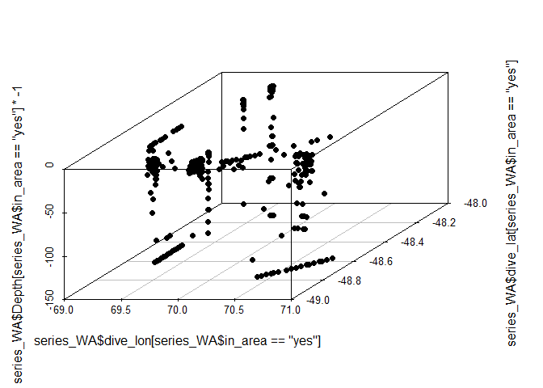

```r
##Just another way to look at dive depths
scatterplot3d(series_WA$dive_lon[series_WA$in_area=="yes"], y=series_WA$dive_lat[series_WA$in_area=="yes"], z=series_WA$Depth[series_WA$in_area=="yes"]*-1, pch=19)
```

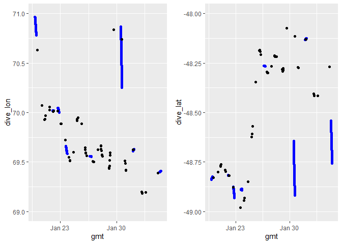

```r
dive_lon <- ggplot(series_WA[series_WA$in_area=="yes",], aes(gmt, dive_lon)) + geom_point(col="blue")

plot1 <- dive_lon +
  geom_point(data=mpm_KI_srw[mpm_KI_srw$id=="235414_1",], aes(x=date, y=lon)) +
  xlim(min(series_WA$gmt[series_WA$in_area=="yes"]), max(series_WA$gmt[series_WA$in_area=="yes"])) +
  ylim(69,71)

dive_lat<- ggplot(series_WA[series_WA$in_area=="yes",], aes(gmt, dive_lat)) + geom_point(col="blue")

plot2 <- dive_lat +
  geom_point(data=mpm_KI_srw[mpm_KI_srw$id=="235414_1",], aes(x=date, y=lat)) +
  xlim(min(series_WA$gmt[series_WA$in_area=="yes"]), max(series_WA$gmt[series_WA$in_area=="yes"])) +
  ylim(-49, -48)


grid.arrange(plot1, plot2, ncol=2)
```

And on an actual map…

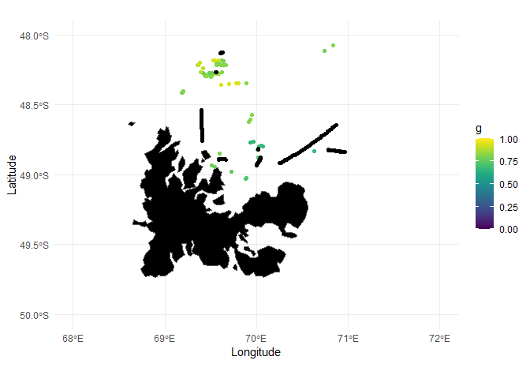

```r
ggplot(map_df) +
  geom_sf(fill = "black", lwd = 0) +
  geom_point(data = mpm_KI_srw[mpm_KI_srw$in_area=="yes"& mpm_KI_srw$id=="235414_1",], size=1.5, aes(lon, lat, colour = g))  +
 xlim(68,72) +
  ylim(-50, -48) +
  theme_minimal()  +
  sc +
  xlab("Longitude") +
  ylab("Latitude") +
   geom_point(data = series_WA, size=1.5, aes(dive_lon, dive_lat))
```

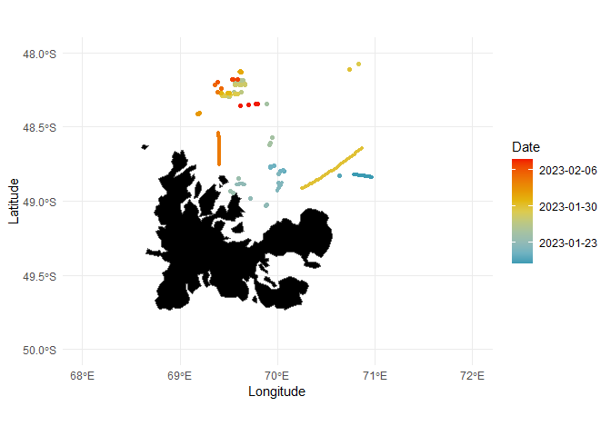

```r
## What about against the 6h time step dataset?
#ggplot(map_df) +
#  geom_sf(fill = "black", lwd = 0) +
#  geom_point(data = mpm_KI_srw_6h[mpm_KI_srw_6h$in_area=="yes"& #mpm_KI_srw_6h$id=="235414_1",], size=1.5, aes(lon, lat, colour = g))  +
# xlim(68,72) +
#  ylim(-50, -48) +
#  theme_minimal()  +
#  sc +
#  xlab("Longitude") +
#  ylab("Latitude") +
#   geom_point(data = series_WA, size=1.5, aes(dive_lon, dive_lat))


## Pair this with date
lab_dates <- with(series_WA[series_WA$in_area=="yes",], pretty(seq(min(gmt),
                                             max(gmt), l = 7))) %>% as.Date()

ggplot(map_df) +
  geom_sf(fill = "black", lwd = 0) +
  geom_point(data = series_WA[series_WA$in_area=="yes",], size=1.2, aes(dive_lon, dive_lat, colour = as.numeric(as.Date(gmt))))  +
  scale_colour_gradientn(breaks = as.numeric(lab_dates), colours = wes_palette(name = "Zissou1",type = "continuous"), labels = lab_dates, name= "Date") +
   xlim(68,72) +
  ylim(-50, -48) +
  theme_minimal()  +
  xlab("Longitude") +
  ylab("Latitude") +
  geom_point(data = mpm_KI_srw[mpm_KI_srw$in_area=="yes"& mpm_KI_srw$id=="235414_1",], size=1.5, aes(lon, lat, colour = as.numeric(as.Date(date))))
```

```r
##6h time step
#ggplot(map_df) +
#  geom_sf(fill = "black", lwd = 0) +
#  geom_point(data = series_WA[series_WA$in_area=="yes",], size=1.2, #aes(dive_lon, dive_lat, colour = as.numeric(as.Date(gmt))))  +
#  scale_colour_gradientn(breaks = as.numeric(lab_dates), colours = #wes_palette(name = "Zissou1",type = "continuous"), labels = lab_dates, #name= "Date") +
#   xlim(68,72) +
#  ylim(-50, -48) +
#  theme_minimal()  +
#  xlab("Longitude") +
#  ylab("Latitude") +
#  geom_point(data = mpm_KI_srw_6h[mpm_KI_srw_6h$in_area=="yes"& #mpm_KI_srw_6h$id=="235414_1",], size=1.5, aes(lon, lat, colour = #as.numeric(as.Date(date))))
```

I don’t trust the way the move persistence model has assigned locations to the dives. Because of the large gaps within the location data, we can probably never hold much confidence in the locations assigned to the dives.  
We can look at dive behaviour more generally around Kerguelen and specifically within those high time spent areas (assuming there is dive data for those areas) by pulling out dive behaviour within a certain time window.

```r
#max(series_WA$Depth[series_WA$in_area=="yes"])
```

Within this time series data, the maximum dive depth achieved by 235414 around Kerguelen was 150 m.

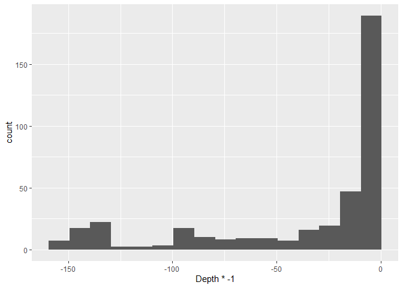

```r
ggplot(series_WA[series_WA$in_area=="yes",], aes(x=Depth*-1)) + geom_histogram(binwidth = 10, boundary = 0.5)
```

Within the time series data, all dives are less than (equal to) 150m and most dives are within 50m.

What do the other dive data sets tell us?  
**6- DIVING BEHAVIOUR - DIVE SHAPES**  
This data set assigns a start and end time to a dive, assigns a dive shape according to bottom time and also provides depth and duration details.

```r
start <- ymd_hms("2023-01-20 02:47:39", tz="GMT")
end <- ymd_hms("2023-02-08 02:57:11", tz="GMT")

behav_WA$Start <- as.POSIXct(behav_WA$Start, format = "%H:%M:%S %d-%b-%Y", tz="GMT")
behav_WA$End <- as.POSIXct(behav_WA$End, format = "%H:%M:%S %d-%b-%Y", tz="GMT")

behav_WA$in_area <- "no"
behav_WA$in_area[behav_WA$Start >= start & behav_WA$End <= end] <- "yes"

### Assign dive shape location using the state space model
behav_WA$seg_id <- "235414_0"
behav_WA$seg_id[as.Date(behav_WA$End) >= locs_235414$date[locs_235414$id=="235414_1"][1]] <- "235414_1"

#prediction times must be specified as a data.frame with id and POSIXt dates
pred_gmt_behav <- behav_WA[behav_WA$What=="Dive",]
pred_gmt_behav <- pred_gmt_behav[,c("Start", "seg_id")]
colnames(pred_gmt_behav) <- c("date", "id")

mp_behav <- fit_ssm(locs_235414, vmax=10, model='crw', time.step=pred_gmt_behav, map = list(psi = factor(NA)), control = ssm_control(verbose = 0))
```

```r
#ggsave(map(mp_behav, what="predicted"), file = paste(file.path(here::here('Outputs')), "/dive_shape_locations_235414.jpeg", sep=""), dpi = 300, width = 14, height = 8, bg="white")

shape <- behav_WA[behav_WA$What=="Dive",]
dive_shape_locs <- grab(mp_behav, what = "predicted")

shape$dive_shape_lon <- dive_shape_locs$lon
shape$dive_shape_lat <- dive_shape_locs$lat

#### Pull out bathymetric depth
coordinates(shape) <- c("dive_shape_lon", "dive_shape_lat")
bathy_extract <- raster::extract(bathy_geb, shape)
shape$bathy <- bathy_extract
shape <- data.frame(shape)

table(shape$Shape[shape$in_area=="yes"]) ## get rid of the unknown one then visualise
```

```
##
##  Square       U Unknown       V
##     105      79       1      30
```

```r
shape_no_unknown <- shape[!shape$Shape=="Unknown",]
```

In the Kerguelen region, there are a total of 214 dives that have been assigned a dive shape.

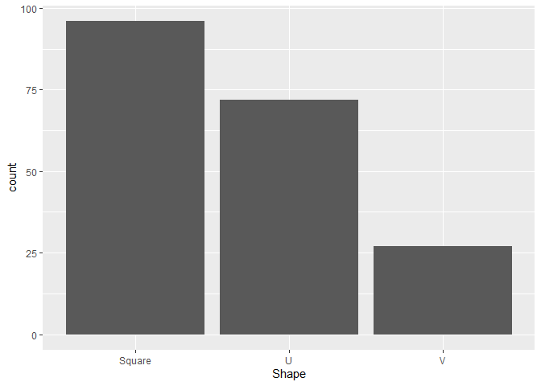

```r
shape_bp <- shape_no_unknown[shape$in_area=="yes",]
shape_bp <- shape_bp[!is.na(shape_bp$Shape),]
ggplot(shape_bp) + geom_bar(aes(x = Shape))
```

Dip into dive durations - note duration is given in seconds so it appears in plots as /60 to provide the minutes equivalent.

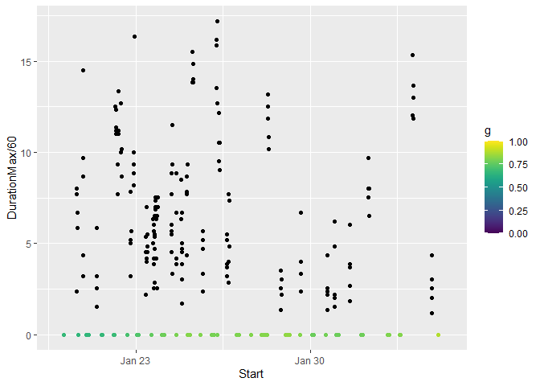

```r
p_dur <- ggplot(shape_no_unknown[shape_no_unknown$in_area=="yes",], aes(Start, DurationMax/60)) + geom_point()

#Add the behavioural index derived from the horizontal movement
p_dur +
  geom_point(data=mpm_KI_srw[mpm_KI_srw$id=="235414_1",], aes(x=date, y=0, colour=g)) +
  xlim(min(series_WA$gmt[series_WA$in_area=="yes"]), max(series_WA$gmt[series_WA$in_area=="yes"])) +
  sc
```

The longest dive is 17.1833333 min, which seems reasonable.  
Take a look at the relationship between dive shape, duration and depth.

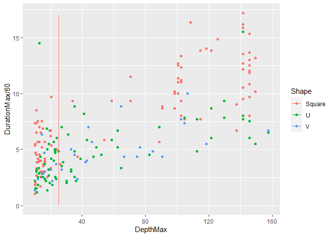

```r
ggplot(shape_no_unknown[shape_no_unknown$in_area=="yes",], aes(DepthMax, DurationMax/60, colour=Shape)) + geom_point() + geom_segment((aes(x=25, xend=25, y=0, yend=17)))
```

We could possibly split dives into shallow and deep - it’s not incredibly clear cut but the cutoff point is probably around 25m.

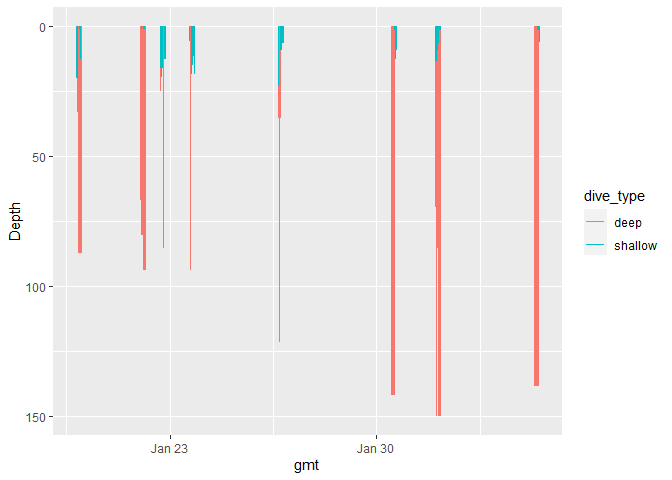

```r
series_WA$dive_type <- "shallow"
series_WA$dive_type[series_WA$Depth >= 25] <- "deep"

ggplot(series_WA[series_WA$in_area=="yes",], aes(gmt, Depth)) +
  geom_segment(aes(x=gmt, xend=gmt, y=0, yend=Depth, colour=dive_type)) +
  scale_y_reverse()
```

Do we see certain dive shapes occur more often during shallow versus deep dives?

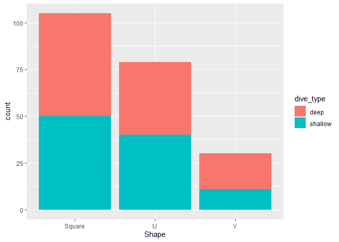

```r
shape_no_unknown$dive_type <- "shallow"
shape_no_unknown$dive_type[shape_no_unknown$DepthMax >= 25] <- "deep"

g <- ggplot(shape_no_unknown[shape_no_unknown$in_area=="yes",], aes(Shape))
g + geom_bar(aes(fill = dive_type))
```

**7- DIURNAL DIVE INFORMATION**  
Just need to extract the times of sunrise/sunset for the dates of interest for a single location representing Kerguelen in general - perhaps 48.5S, 70E.

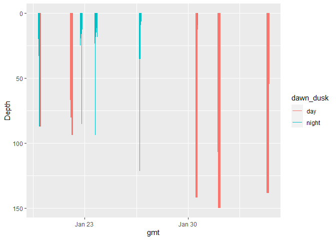

```r
sr <- sunriset(
matrix(c(70, -48.5), nrow = 1),
as.POSIXct(seq(as.Date("2023-01-19"), as.Date("2023-02-08"), by="day", tz = "UTC")),
direction=c('sunrise'),
crs = sf::st_crs(4326),
POSIXct.out=TRUE
)

ss <- sunriset(
matrix(c(70, -48.5), nrow = 1),
as.POSIXct(seq(as.Date("2023-01-19"), as.Date("2023-02-08"), by="day", tz = "UTC")),
direction=c('sunset'),
crs = sf::st_crs(4326),
POSIXct.out=TRUE
)

sr_ss <- cbind(sr, ss)
sr_ss$ref_date <- as.POSIXct(seq(as.Date("2023-01-19"), as.Date("2023-02-08"), by="day", tz = "UTC"))

#civil dawn
cd <- crepuscule(
matrix(c(70, -48.5), nrow = 1),
as.POSIXct(seq(as.Date("2023-01-19"), as.Date("2023-02-08"), by="day", tz = "UTC")),
direction=c('dawn'),
solarDep = 6,
crs = sf::st_crs(4326),
POSIXct.out=TRUE
)

#civil twilight/dusk
ct <- crepuscule(
matrix(c(70, -48.5), nrow = 1),
as.POSIXct(seq(as.Date("2023-01-19"), as.Date("2023-02-08"), by="day", tz = "UTC")),
direction=c('dusk'),
solarDep = 6,
crs = sf::st_crs(4326),
POSIXct.out=TRUE
)

sr_ss$civil_dawn <- cd$time
sr_ss$civil_dusk <- ct$time

## Now assign dives to within dusk and dawn or not - dd_day will indicate whether located between dusk and dawn
## remember to set all out of area to NA
## also need to use local time...(UTC + 5)

dtes <- unique(as.Date(series_WA$gmt[series_WA$in_area=="yes"] + 5*60*60))

series_bind <- series_WA[1,]
series_bind$dawn_dusk <- "to assign"

for(i in 1:length(dtes)){
  sub_series <- series_WA[as.Date(series_WA$gmt + 5*60*60) == dtes[i],]
  sr_ss_match <- sr_ss[sr_ss$ref_date==dtes[i],]
  sub_series$dawn_dusk <- "night"
  sub_series$dawn_dusk[sub_series$gmt+ 5*60*60 >= sr_ss_match$civil_dawn+ 5*60*60 & sub_series$gmt+ 5*60*60 <= sr_ss_match$civil_dusk+ 5*60*60] <- "day"
  series_bind <- rbind(series_bind,sub_series)

}

kerg_dive_dd <- series_bind[-1,]

ggplot(kerg_dive_dd, aes(gmt, Depth)) +
  geom_segment(aes(x=gmt, xend=gmt, y=0, yend=Depth, colour=dawn_dusk)) +
  scale_y_reverse()
```